# Štatistické metódy vyhodnocovania experimentov

Tomáš Bacigál

3.3.2021

# 4 Bodové a intervalové odhady

Veľa krát poznáme triedu rozdelenia náhodnej premennej (NP) a potrebujeme si vytvoriť predstavu o jeho parametroch, ktoré nepoznáme, napr. o strednej hodnote či disperzii normálneho rozdelenia. Vieme vypočítať priemernú hodnotu či štandardnú odchýlku z výberu (pozorovaných hodnôt) - bodové odhady, ktoré sú so zvyšujúcim sa rozsahom výberu presnejšie. Ale ako presné? O tom hovoria intervaly spoľahlivosti.

## 4.1 Pomer (proportion)

**Príklad:**

42 zo 100 opýtaných nakupujúcich má rado značku ABC. Ako prezentovať preferenciu širšej populácie ľudí?

Riešenie:  
Bodovy odhad je zjavný už z prieskumu.

```r
p <- 42/100
```

Ak X by bola náhodná premenná, že sa (náhodne vybraný) človek buď rozhodne pre ABC (X=1) alebo nie (X=0), pomer p by sme dostali ako priemer z realizácií X, teda p=sum(x)/n, kde x by boli konkrétne odpovede x=(1,1,0,1,0,0,0,1,…). Keďže X ma alternatívne rozdelenie (s parametrom a zároveň strednou hodnotou p), jeho rozptyl je D(X)=p(1-p). Náhodná premenná Y=sum(X)/n má tiež strednú hodnotu E(Y)=E(X)=p, no s rozptylom D(Y)=p(1-p)/n. Teda čím by sme mali väčší výber respondentov, tým “užšia by bola slučka” okolo odhadovaného (neznámeho) parametra p. Pri dostatočne veľkom n bude mat nah.premenná Z=[Y-E(Y)]/SD(Y) normálne rozdelenie N(0,1), pričom SD(Y)=sqrt(D(Y)/n)=SE(X) môžme odhadnúť

```r
( se <- sqrt(p*(1-p)/100) )
```

```
## [1] 0.04935585
```

tak náh.premenná Y bude (napr. s 1-alpha = 95% pravdepodobnosťou)

```r
alpha <- 0.05
```

nadobúdať hodnoty medzi hranicami

```r
p + c(-1,1)*qnorm(1-alpha/2)*se
```

```
## [1] 0.3232643 0.5167357
```

Podobný výsledok (počitaný s presnou hodnotou SE) dá vstavaná funkcia

```r
prop.test(42, n=100, conf.level=1-alpha)$conf.int
```

```
## [1] 0.3233236 0.5228954
## attr(,"conf.level")
## [1] 0.95
```

Keby sme sa napr. pýtali iba 20 ludi (a v rôznych dňoch), počas 50 dní by sme mohli dostať takéto 90% intervaly pre parameter p

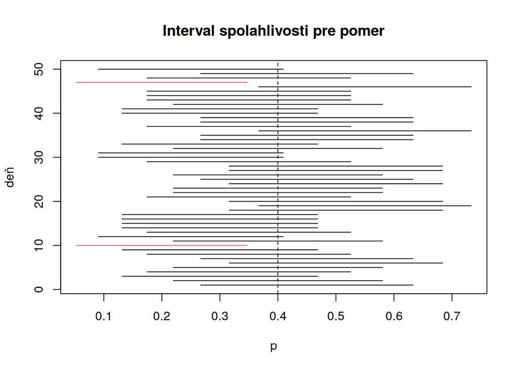

```r
m <- 50; n <- 20; p0 <- 0.4;
p <-  rbinom(m,n,p0)/n
se <- sqrt(p*(1-p)/n)
alpha <- 0.10
tmp <- rbind(p - qnorm(1-alpha/2)*se, p + qnorm(1-alpha/2)*se)
matplot(tmp,
        rbind(1:m,1:m),
        col = abs(apply(tmp, 2, findInterval, x = p0) - 1) + 1,
        type="l", lty=1, xlab="p", ylab="deň", main="Interval spolahlivosti pre pomer"
)
abline(v=p0, lty=2) # skutočná hodnota parametra
```

## 4.2 Stredná hodnota a rozptyl normálneho rozdelenia

Ak poznáme rozptyl náhodnej premennej X a 1) jej rozdelenie je normálne alebo 2) n je dostatočne veľké na aplikovanie centrálnej limitnej vety, potom na výpočet intervalových odhadov strednej hodnoty možno použiť kvantily normálneho rozdelenia, pretože Z=[X-E(X)]/SE(X) má N(0,1) rozdelenie. Ak však rozptyl nepoznáme, Z ma Studentovo t-rozdelenie s n-1 stupnami voľnosti (a označuje sa T namiesto Z).

**Príklad:**

Predstavme si človeka, ktorý sa pravideľne váži, X je jeho hmotnosť (a x je vektor pozorovaní). Nájdime 95% interval spoľahlivosti pre priemer (=intervalový odhad E(X)).

```r
x <- c(175, 176, 173, 175, 174, 173, 173, 176, 173, 179)
```

Riešenie:  
Predpokladajme najprv, že SD(X)=1.5 a X má normálne rozdelenie.

```r
( n <- length(x) )
```

```
## [1] 10
```

```r
( xmean <- mean(x) )
```

```
## [1] 174.7
```

```r
xmean + c(-1,1)*qnorm(1-0.05/2)*1.5/sqrt(n)  # IS pri znamom sigma (SD)
```

```
## [1] 173.7703 175.6297
```

V praxi je SD málokedy známe, potom na výpočet IS použijeme jeho odhad

```r
( xsd <- sd(x) )
```

```
## [1] 1.946507
```

```r
xmean + c(-1,1) * qt(1-0.05/2, n-1) * xsd/sqrt(n)
```

```
## [1] 173.3076 176.0924
```

ktorý je väčšinou širší, pretože t-rozdelenie má hrubšie chvosty (pozri graf v predošlom cvičení) než N(0,1). Alternatívne:

```r
t.test(x)$conf.int
```

```
## [1] 173.3076 176.0924
## attr(,"conf.level")
## [1] 0.95
```

Ak by sme mali dôvod pochybovať o normálnom rozdelení X, či už na základe popisnej štatistiky alebo testu normality, vhodnejšou mierou polohy by bol medián.

**Príklad:**

Majme náhodnú premennú plat s nasledovnými pozorovaniami (pay of CEO’s, v roku 2001 v dolároch). Aký je bodový a intervalový odhad mediánu?

```r
x <- c(110, 12, 2.5, 98, 1017, 540, 54, 4.3, 150, 432)
```

Riešenie:

```r
median(x)  # výberový medián = bodový odhad
```

```
## [1] 104
```

```r
wilcox.test(x, conf.int=TRUE)$conf.int  # intervalový odhad
```

```
## [1]  33.0 514.5
## attr(,"conf.level")
## [1] 0.95
```

Interval je dosť široký, pretože rozsah n je malý.  
Nemá zmysel ani uvažovať o normálnosti rozdelenia:

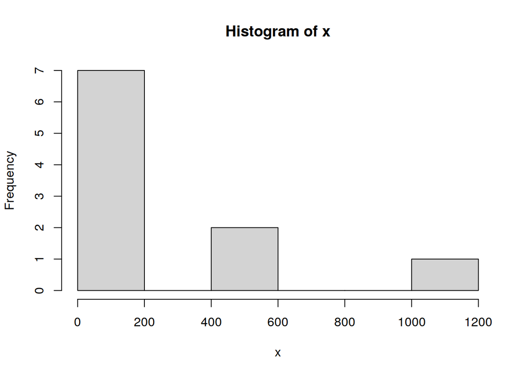

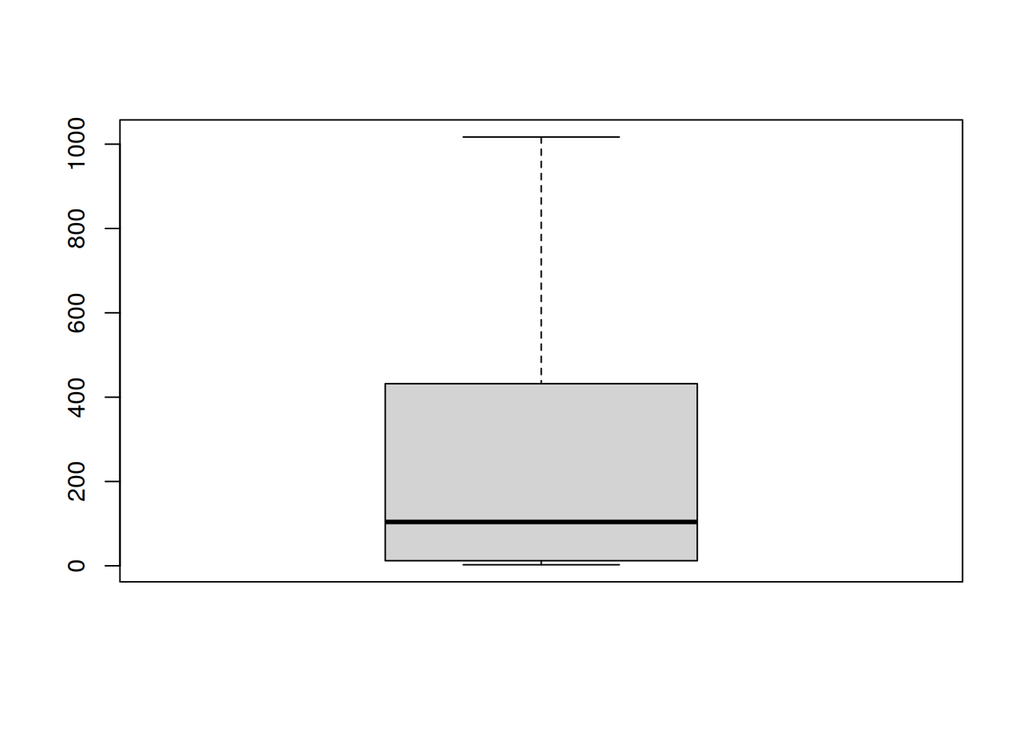

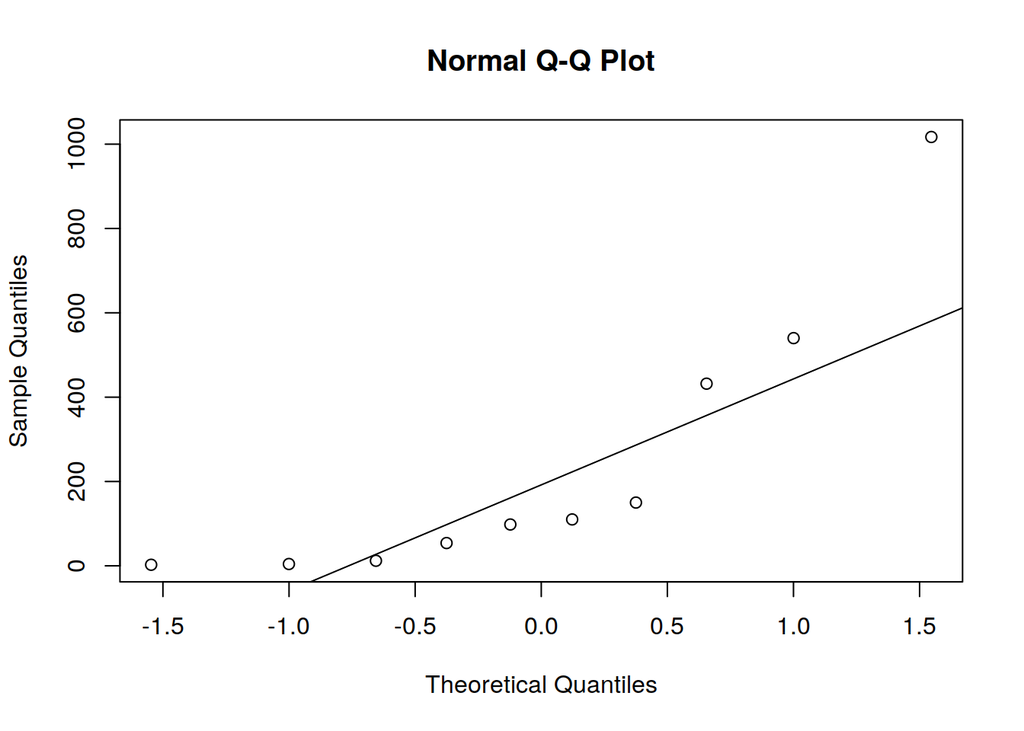

```r
hist(x)
boxplot(x)
qqnorm(x); qqline(x)
```

**Príklad** (Markechová 2011a, Príklad 6.4, str. 155)

Pre určenie poistnej zásoby určitého druhu tovaru je potrebné odhadnúť 95-percentným intervalovým odhadom strednú hodnotu a rozptyl času, za aký dodávateľ vybaví objednávku. Náhodne bolo vybratých 20 objednávok, u ktorých sa zaznamenala dĺžka ich vybavenia v dňoch. Boli získané tieto údaje:

```r
x <- c(18, 12, 18,13,13,16,11,17,20,14,15,14,15,16,15,17,13,14,16,13)
m <- mean(x)  # bodový odhad strednej hodnoty
s <- sd(x)  # bodový odhad smerodajnej odchýlky
n <- length(x)  # rozsah výberu
alfa <- 0.05  # hladina významnosti
q <- qt(1-alfa/2, df=n-1)  # 97.5% kvantil t-rozdelenia s 19 stupňami voľnosti

m + c(D=-1, H=1) * q * s / sqrt(n)  # interval spoľahlivosti pre strednú hodnotu
```

```
##        D        H
## 13.93709 16.06291
```

```r
c( t.test(x, conf.level = 0.95)$conf.int ) # vstavanou funkciou
```

```
## [1] 13.93709 16.06291
```

```r
q <- qchisq(c(alfa/2, 1-alfa/2), df=n-1)
sqrt((n-1)/c(D=q[2], H=q[1]))*s  # interval spoľahlivosti pre smerodajnú odchýlku
```

```
##        D        H
## 1.727150 3.317104
```

alternatívne pomocou:

```r
sqrt(c( EnvStats::varTest(x, alternative = "two.sided", conf.level = 1-alfa)$conf.int ))
```

```
##      LCL      UCL
## 1.727150 3.317104
```

ľavostranné intervalové odhady:

```r
c(D = m - qt(1-alfa, df=n-1) * s / sqrt(n), H = Inf)  # pre strednu hodnotu
```

```
##        D        H
## 14.12189      Inf
```

```r
c(D = sqrt( (n-1)/qchisq(1-alfa,df=n-1) ) * s, H = Inf)  # pre stand.odchylku
```

```
##        D        H
## 1.803084      Inf
```

## 4.3 Literatúra

Verzani: Simple R

Pavlík a kol. 2005: Aplikovaná statistika.

Pavlík a kol. 2012: Sbírka příkladú z aplikované statistiky

Litschmannová 2011: Úvod do statistiky.

Litschmannová: Úvod do statistiky (interaktivní učební text) - Řešené příklady

Markechová a kol. 2011a: Úvod do štatistiky pre pedagógov.

Markechová a kol. 2011b: Štatistické metódy a ich aplikácie

Kalina a kol. 2010: Základy pravdepodobnosti a matematickej štatistiky